# Risk Factor Analysis

## Outcome Variable

**Outcome Variable:** ever_stunted

## Predictor Variables

**Intervention Variable:** predfeed3

**Adjustment Set:**

- arm
- month
- brthmon
- W_mage
- meducyrs
- feducyrs
- hhwealth_quart
- hfoodsec
- W_mhtcm
- vagbrth
- W_gagebrth
- W_birthwt
- W_birthlen
- W_nrooms
- W_nchldlt5
- W_parity
- impfloor
- impsan
- safeh20
- delta_W_mage
- delta_meducyrs
- delta_feducyrs
- delta_hhwealth_quart
- delta_hfoodsec
- delta_W_mhtcm
- delta_vagbrth
- delta_W_gagebrth
- delta_W_birthwt
- delta_W_birthlen
- delta_W_nrooms
- delta_W_nchldlt5
- delta_W_parity
- delta_impfloor
- delta_impsan
- delta_safeh20

## Stratifying Variables

The analysis was stratified on these variable(s):

- agecat
- studyid
- country

## Data Summary

| agecat | studyid | country | predfeed3 | ever_stunted | n_cell | n |
| --- | --- | --- | --- | --- | --- | --- |
| 0-24 months (no birth st.) | ki0047075b-MAL-ED | BANGLADESH | 1 | 0 | 85 | 206 |
| 0-24 months (no birth st.) | ki0047075b-MAL-ED | BANGLADESH | 1 | 1 | 91 | 206 |
| 0-24 months (no birth st.) | ki0047075b-MAL-ED | BANGLADESH | 0 | 0 | 13 | 206 |
| 0-24 months (no birth st.) | ki0047075b-MAL-ED | BANGLADESH | 0 | 1 | 17 | 206 |
| 0-24 months (no birth st.) | ki0047075b-MAL-ED | BRAZIL | 1 | 0 | 93 | 202 |
| 0-24 months (no birth st.) | ki0047075b-MAL-ED | BRAZIL | 1 | 1 | 17 | 202 |
| 0-24 months (no birth st.) | ki0047075b-MAL-ED | BRAZIL | 0 | 0 | 81 | 202 |
| 0-24 months (no birth st.) | ki0047075b-MAL-ED | BRAZIL | 0 | 1 | 11 | 202 |
| 0-24 months (no birth st.) | ki0047075b-MAL-ED | INDIA | 1 | 0 | 61 | 200 |
| 0-24 months (no birth st.) | ki0047075b-MAL-ED | INDIA | 1 | 1 | 94 | 200 |
| 0-24 months (no birth st.) | ki0047075b-MAL-ED | INDIA | 0 | 0 | 33 | 200 |
| 0-24 months (no birth st.) | ki0047075b-MAL-ED | INDIA | 0 | 1 | 12 | 200 |
| 0-24 months (no birth st.) | ki0047075b-MAL-ED | NEPAL | 1 | 0 | 91 | 209 |
| 0-24 months (no birth st.) | ki0047075b-MAL-ED | NEPAL | 1 | 1 | 33 | 209 |
| 0-24 months (no birth st.) | ki0047075b-MAL-ED | NEPAL | 0 | 0 | 63 | 209 |
| 0-24 months (no birth st.) | ki0047075b-MAL-ED | NEPAL | 0 | 1 | 22 | 209 |
| 0-24 months (no birth st.) | ki0047075b-MAL-ED | PERU | 1 | 0 | 72 | 251 |
| 0-24 months (no birth st.) | ki0047075b-MAL-ED | PERU | 1 | 1 | 98 | 251 |
| 0-24 months (no birth st.) | ki0047075b-MAL-ED | PERU | 0 | 0 | 29 | 251 |
| 0-24 months (no birth st.) | ki0047075b-MAL-ED | PERU | 0 | 1 | 52 | 251 |
| 0-24 months (no birth st.) | ki0047075b-MAL-ED | SOUTH AFRICA | 1 | 0 | 37 | 246 |
| 0-24 months (no birth st.) | ki0047075b-MAL-ED | SOUTH AFRICA | 1 | 1 | 51 | 246 |
| 0-24 months (no birth st.) | ki0047075b-MAL-ED | SOUTH AFRICA | 0 | 0 | 77 | 246 |
| 0-24 months (no birth st.) | ki0047075b-MAL-ED | SOUTH AFRICA | 0 | 1 | 81 | 246 |
| 0-24 months (no birth st.) | ki0047075b-MAL-ED | TANZANIA, UNITED REPUBLIC OF | 1 | 0 | 17 | 211 |
| 0-24 months (no birth st.) | ki0047075b-MAL-ED | TANZANIA, UNITED REPUBLIC OF | 1 | 1 | 66 | 211 |
| 0-24 months (no birth st.) | ki0047075b-MAL-ED | TANZANIA, UNITED REPUBLIC OF | 0 | 0 | 19 | 211 |
| 0-24 months (no birth st.) | ki0047075b-MAL-ED | TANZANIA, UNITED REPUBLIC OF | 0 | 1 | 109 | 211 |
| 0-24 months (no birth st.) | ki1000109-EE | PAKISTAN | 1 | 0 | 30 | 248 |
| 0-24 months (no birth st.) | ki1000109-EE | PAKISTAN | 1 | 1 | 202 | 248 |

[output cut: 102 more lines]

The following strata were considered:

- agecat: 0-24 months (no birth st.), studyid: ki0047075b-MAL-ED, country: BANGLADESH
- agecat: 0-24 months (no birth st.), studyid: ki0047075b-MAL-ED, country: BRAZIL
- agecat: 0-24 months (no birth st.), studyid: ki0047075b-MAL-ED, country: INDIA
- agecat: 0-24 months (no birth st.), studyid: ki0047075b-MAL-ED, country: NEPAL
- agecat: 0-24 months (no birth st.), studyid: ki0047075b-MAL-ED, country: PERU
- agecat: 0-24 months (no birth st.), studyid: ki0047075b-MAL-ED, country: SOUTH AFRICA
- agecat: 0-24 months (no birth st.), studyid: ki0047075b-MAL-ED, country: TANZANIA, UNITED REPUBLIC OF
- agecat: 0-24 months (no birth st.), studyid: ki1000109-EE, country: PAKISTAN
- agecat: 0-24 months (no birth st.), studyid: ki1113344-GMS-Nepal, country: NEPAL
- agecat: 0-24 months (no birth st.), studyid: kiGH5241-JiVitA-3, country: BANGLADESH
- agecat: 0-24 months (no birth st.), studyid: kiGH5241-JiVitA-4, country: BANGLADESH
- agecat: 0-6 months (no birth st.), studyid: ki0047075b-MAL-ED, country: BANGLADESH
- agecat: 0-6 months (no birth st.), studyid: ki0047075b-MAL-ED, country: BRAZIL
- agecat: 0-6 months (no birth st.), studyid: ki0047075b-MAL-ED, country: INDIA
- agecat: 0-6 months (no birth st.), studyid: ki0047075b-MAL-ED, country: NEPAL
- agecat: 0-6 months (no birth st.), studyid: ki0047075b-MAL-ED, country: PERU
- agecat: 0-6 months (no birth st.), studyid: ki0047075b-MAL-ED, country: SOUTH AFRICA
- agecat: 0-6 months (no birth st.), studyid: ki0047075b-MAL-ED, country: TANZANIA, UNITED REPUBLIC OF
- agecat: 0-6 months (no birth st.), studyid: ki1000109-EE, country: PAKISTAN
- agecat: 0-6 months (no birth st.), studyid: ki1113344-GMS-Nepal, country: NEPAL
- agecat: 0-6 months (no birth st.), studyid: kiGH5241-JiVitA-3, country: BANGLADESH
- agecat: 0-6 months (no birth st.), studyid: kiGH5241-JiVitA-4, country: BANGLADESH
- agecat: 6-24 months, studyid: ki0047075b-MAL-ED, country: BANGLADESH
- agecat: 6-24 months, studyid: ki0047075b-MAL-ED, country: BRAZIL
- agecat: 6-24 months, studyid: ki0047075b-MAL-ED, country: INDIA
- agecat: 6-24 months, studyid: ki0047075b-MAL-ED, country: NEPAL
- agecat: 6-24 months, studyid: ki0047075b-MAL-ED, country: PERU
- agecat: 6-24 months, studyid: ki0047075b-MAL-ED, country: SOUTH AFRICA
- agecat: 6-24 months, studyid: ki0047075b-MAL-ED, country: TANZANIA, UNITED REPUBLIC OF
- agecat: 6-24 months, studyid: ki1000109-EE, country: PAKISTAN
- agecat: 6-24 months, studyid: ki1113344-GMS-Nepal, country: NEPAL
- agecat: 6-24 months, studyid: kiGH5241-JiVitA-3, country: BANGLADESH
- agecat: 6-24 months, studyid: kiGH5241-JiVitA-4, country: BANGLADESH

### Dropped Strata

Some strata were dropped due to rare outcomes:

- agecat: 0-24 months (no birth st.), studyid: ki1000109-EE, country: PAKISTAN
- agecat: 0-24 months (no birth st.), studyid: kiGH5241-JiVitA-4, country: BANGLADESH
- agecat: 0-6 months (no birth st.), studyid: kiGH5241-JiVitA-4, country: BANGLADESH
- agecat: 6-24 months, studyid: ki0047075b-MAL-ED, country: BRAZIL
- agecat: 6-24 months, studyid: ki1000109-EE, country: PAKISTAN
- agecat: 6-24 months, studyid: kiGH5241-JiVitA-4, country: BANGLADESH

## Methods Detail

We’re interested in the causal parameters $E[Y_a]$ for all values of $a \in \mathcal{A}$. These parameters represent the mean outcome if, possibly contrary to fact, we intervened to set all units to have $A=a$. Under the randomization and positivity assumptions, these are identified by the statistical parameters $\psi_a=E_W[E_{Y|A,W}(Y|A=a,W)]$. In addition, we’re interested in the mean of $Y$, $E[Y]$ under no intervention (the observed mean). We will estimate these parameters by using SuperLearner to fit the relevant likelihood factors – $E_{Y|A,W}(Y|A=a,W)$ and $p(A=a|W)$, and then updating our likelihood fit using a joint TMLE.

For unadjusted analyses ($W=\{\}$), initial likelihoods were estimated using Lrnr_glm to estimate the simple $E(Y|A)$ and Lrnr_mean to estimate $p(A)$. For adjusted analyses, a small library containing Lrnr_glmnet, Lrnr_xgboost, and Lrnr_mean was used.

Having estimated these parameters, we will then use the delta method to estimate relative risks and attributable risks relative to a prespecified baseline level of $A$.

# Results Detail

## Results Plots

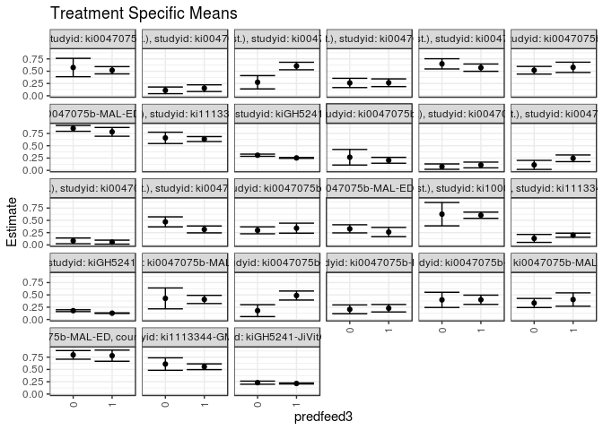

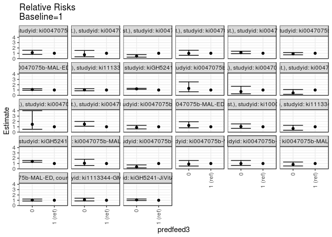

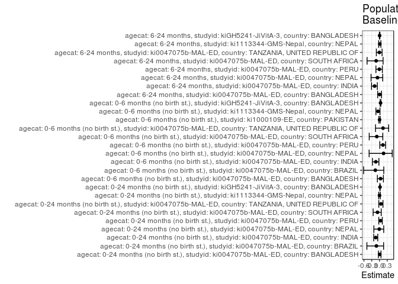

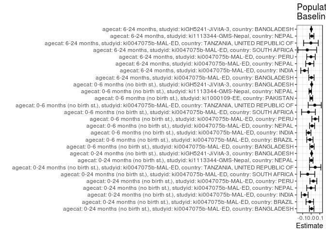

## Results Table

### Parameter: TSM

| agecat | studyid | country | intervention_level | baseline_level | estimate | ci_lower | ci_upper |
| --- | --- | --- | --- | --- | --- | --- | --- |
| 0-24 months (no birth st.) | ki0047075b-MAL-ED | BANGLADESH | 1 | NA | 0.5191834 | 0.4455497 | 0.5928171 |
| 0-24 months (no birth st.) | ki0047075b-MAL-ED | BANGLADESH | 0 | NA | 0.5745361 | 0.3879720 | 0.7611002 |
| 0-24 months (no birth st.) | ki0047075b-MAL-ED | BRAZIL | 1 | NA | 0.1549987 | 0.0872997 | 0.2226978 |
| 0-24 months (no birth st.) | ki0047075b-MAL-ED | BRAZIL | 0 | NA | 0.1108339 | 0.0431323 | 0.1785354 |
| 0-24 months (no birth st.) | ki0047075b-MAL-ED | INDIA | 1 | NA | 0.6053672 | 0.5289605 | 0.6817739 |
| 0-24 months (no birth st.) | ki0047075b-MAL-ED | INDIA | 0 | NA | 0.2750703 | 0.1397691 | 0.4103715 |
| 0-24 months (no birth st.) | ki0047075b-MAL-ED | NEPAL | 1 | NA | 0.2653668 | 0.1869420 | 0.3437916 |
| 0-24 months (no birth st.) | ki0047075b-MAL-ED | NEPAL | 0 | NA | 0.2610546 | 0.1669252 | 0.3551840 |
| 0-24 months (no birth st.) | ki0047075b-MAL-ED | PERU | 1 | NA | 0.5722285 | 0.4977970 | 0.6466600 |
| 0-24 months (no birth st.) | ki0047075b-MAL-ED | PERU | 0 | NA | 0.6494572 | 0.5458312 | 0.7530833 |
| 0-24 months (no birth st.) | ki0047075b-MAL-ED | SOUTH AFRICA | 1 | NA | 0.5783372 | 0.4738541 | 0.6828202 |
| 0-24 months (no birth st.) | ki0047075b-MAL-ED | SOUTH AFRICA | 0 | NA | 0.5188504 | 0.4413248 | 0.5963761 |
| 0-24 months (no birth st.) | ki0047075b-MAL-ED | TANZANIA, UNITED REPUBLIC OF | 1 | NA | 0.7825857 | 0.6933022 | 0.8718692 |
| 0-24 months (no birth st.) | ki0047075b-MAL-ED | TANZANIA, UNITED REPUBLIC OF | 0 | NA | 0.8536787 | 0.7937319 | 0.9136255 |
| 0-24 months (no birth st.) | ki1113344-GMS-Nepal | NEPAL | 1 | NA | 0.6364893 | 0.5862558 | 0.6867227 |
| 0-24 months (no birth st.) | ki1113344-GMS-Nepal | NEPAL | 0 | NA | 0.6603079 | 0.5449320 | 0.7756839 |
| 0-24 months (no birth st.) | kiGH5241-JiVitA-3 | BANGLADESH | 1 | NA | 0.2528202 | 0.2444145 | 0.2612259 |
| 0-24 months (no birth st.) | kiGH5241-JiVitA-3 | BANGLADESH | 0 | NA | 0.3076831 | 0.2851356 | 0.3302306 |
| 0-6 months (no birth st.) | ki0047075b-MAL-ED | BANGLADESH | 1 | NA | 0.2045455 | 0.1448074 | 0.2642835 |
| 0-6 months (no birth st.) | ki0047075b-MAL-ED | BANGLADESH | 0 | NA | 0.2666667 | 0.1080389 | 0.4252944 |
| 0-6 months (no birth st.) | ki0047075b-MAL-ED | BRAZIL | 1 | NA | 0.1090909 | 0.0506872 | 0.1674946 |
| 0-6 months (no birth st.) | ki0047075b-MAL-ED | BRAZIL | 0 | NA | 0.0760870 | 0.0217741 | 0.1303998 |
| 0-6 months (no birth st.) | ki0047075b-MAL-ED | INDIA | 1 | NA | 0.2451613 | 0.1772685 | 0.3130541 |
| 0-6 months (no birth st.) | ki0047075b-MAL-ED | INDIA | 0 | NA | 0.1111111 | 0.0190592 | 0.2031630 |
| 0-6 months (no birth st.) | ki0047075b-MAL-ED | NEPAL | 1 | NA | 0.0564516 | 0.0157324 | 0.0971708 |
| 0-6 months (no birth st.) | ki0047075b-MAL-ED | NEPAL | 0 | NA | 0.0823529 | 0.0237718 | 0.1409340 |
| 0-6 months (no birth st.) | ki0047075b-MAL-ED | PERU | 1 | NA | 0.3151159 | 0.2452565 | 0.3849752 |
| 0-6 months (no birth st.) | ki0047075b-MAL-ED | PERU | 0 | NA | 0.4686785 | 0.3668176 | 0.5705394 |
| 0-6 months (no birth st.) | ki0047075b-MAL-ED | SOUTH AFRICA | 1 | NA | 0.3409348 | 0.2391424 | 0.4427271 |
| 0-6 months (no birth st.) | ki0047075b-MAL-ED | SOUTH AFRICA | 0 | NA | 0.2966263 | 0.2262686 | 0.3669839 |
| 0-6 months (no birth st.) | ki0047075b-MAL-ED | TANZANIA, UNITED REPUBLIC OF | 1 | NA | 0.2618361 | 0.1674231 | 0.3562492 |
| 0-6 months (no birth st.) | ki0047075b-MAL-ED | TANZANIA, UNITED REPUBLIC OF | 0 | NA | 0.3271677 | 0.2449482 | 0.4093871 |
| 0-6 months (no birth st.) | ki1000109-EE | PAKISTAN | 1 | NA | 0.6034483 | 0.5403741 | 0.6665224 |
| 0-6 months (no birth st.) | ki1000109-EE | PAKISTAN | 0 | NA | 0.6250000 | 0.3873044 | 0.8626956 |
| 0-6 months (no birth st.) | ki1113344-GMS-Nepal | NEPAL | 1 | NA | 0.1977401 | 0.1562001 | 0.2392801 |
| 0-6 months (no birth st.) | ki1113344-GMS-Nepal | NEPAL | 0 | NA | 0.1323529 | 0.0517136 | 0.2129923 |
| 0-6 months (no birth st.) | kiGH5241-JiVitA-3 | BANGLADESH | 1 | NA | 0.1284840 | 0.1224572 | 0.1345109 |
| 0-6 months (no birth st.) | kiGH5241-JiVitA-3 | BANGLADESH | 0 | NA | 0.1788553 | 0.1599605 | 0.1977501 |
| 6-24 months | ki0047075b-MAL-ED | BANGLADESH | 1 | NA | 0.4074074 | 0.3242559 | 0.4905589 |
| 6-24 months | ki0047075b-MAL-ED | BANGLADESH | 0 | NA | 0.4285714 | 0.2162335 | 0.6409093 |
| 6-24 months | ki0047075b-MAL-ED | INDIA | 1 | NA | 0.4869565 | 0.3953058 | 0.5786073 |
| 6-24 months | ki0047075b-MAL-ED | INDIA | 0 | NA | 0.1794872 | 0.0586530 | 0.3003214 |
| 6-24 months | ki0047075b-MAL-ED | NEPAL | 1 | NA | 0.2290494 | 0.1529814 | 0.3051174 |
| 6-24 months | ki0047075b-MAL-ED | NEPAL | 0 | NA | 0.2065407 | 0.1170925 | 0.2959888 |
| 6-24 months | ki0047075b-MAL-ED | PERU | 1 | NA | 0.4011317 | 0.3075351 | 0.4947282 |
| 6-24 months | ki0047075b-MAL-ED | PERU | 0 | NA | 0.3985060 | 0.2438432 | 0.5531689 |
| 6-24 months | ki0047075b-MAL-ED | SOUTH AFRICA | 1 | NA | 0.4052598 | 0.2693236 | 0.5411960 |
| 6-24 months | ki0047075b-MAL-ED | SOUTH AFRICA | 0 | NA | 0.3351150 | 0.2425053 | 0.4277248 |
| 6-24 months | ki0047075b-MAL-ED | TANZANIA, UNITED REPUBLIC OF | 1 | NA | 0.7795328 | 0.6665711 | 0.8924944 |
| 6-24 months | ki0047075b-MAL-ED | TANZANIA, UNITED REPUBLIC OF | 0 | NA | 0.7963904 | 0.7084243 | 0.8843566 |
| 6-24 months | ki1113344-GMS-Nepal | NEPAL | 1 | NA | 0.5548284 | 0.4964315 | 0.6132254 |
| 6-24 months | ki1113344-GMS-Nepal | NEPAL | 0 | NA | 0.6096454 | 0.4827485 | 0.7365423 |
| 6-24 months | kiGH5241-JiVitA-3 | BANGLADESH | 1 | NA | 0.2146804 | 0.2048743 | 0.2244865 |
| 6-24 months | kiGH5241-JiVitA-3 | BANGLADESH | 0 | NA | 0.2312310 | 0.1996477 | 0.2628144 |

### Parameter: E(Y)

| agecat | studyid | country | intervention_level | baseline_level | estimate | ci_lower | ci_upper |
| --- | --- | --- | --- | --- | --- | --- | --- |
| 0-24 months (no birth st.) | ki0047075b-MAL-ED | BANGLADESH | NA | NA | 0.5242718 | 0.4559076 | 0.5926361 |
| 0-24 months (no birth st.) | ki0047075b-MAL-ED | BRAZIL | NA | NA | 0.1386139 | 0.0908442 | 0.1863835 |
| 0-24 months (no birth st.) | ki0047075b-MAL-ED | INDIA | NA | NA | 0.5300000 | 0.4606561 | 0.5993439 |
| 0-24 months (no birth st.) | ki0047075b-MAL-ED | NEPAL | NA | NA | 0.2631579 | 0.2033151 | 0.3230007 |
| 0-24 months (no birth st.) | ki0047075b-MAL-ED | PERU | NA | NA | 0.5976096 | 0.5368226 | 0.6583966 |
| 0-24 months (no birth st.) | ki0047075b-MAL-ED | SOUTH AFRICA | NA | NA | 0.5365854 | 0.4741444 | 0.5990263 |
| 0-24 months (no birth st.) | ki0047075b-MAL-ED | TANZANIA, UNITED REPUBLIC OF | NA | NA | 0.8293839 | 0.7785063 | 0.8802614 |
| 0-24 months (no birth st.) | ki1113344-GMS-Nepal | NEPAL | NA | NA | 0.6374408 | 0.5915192 | 0.6833623 |
| 0-24 months (no birth st.) | kiGH5241-JiVitA-3 | BANGLADESH | NA | NA | 0.2580007 | 0.2499160 | 0.2660854 |
| 0-6 months (no birth st.) | ki0047075b-MAL-ED | BANGLADESH | NA | NA | 0.2135922 | 0.1574890 | 0.2696955 |
| 0-6 months (no birth st.) | ki0047075b-MAL-ED | BRAZIL | NA | NA | 0.0940594 | 0.0537041 | 0.1344147 |
| 0-6 months (no birth st.) | ki0047075b-MAL-ED | INDIA | NA | NA | 0.2150000 | 0.1579211 | 0.2720789 |
| 0-6 months (no birth st.) | ki0047075b-MAL-ED | NEPAL | NA | NA | 0.0669856 | 0.0330113 | 0.1009600 |
| 0-6 months (no birth st.) | ki0047075b-MAL-ED | PERU | NA | NA | 0.3625498 | 0.3029582 | 0.4221414 |
| 0-6 months (no birth st.) | ki0047075b-MAL-ED | SOUTH AFRICA | NA | NA | 0.3089431 | 0.2510854 | 0.3668008 |
| 0-6 months (no birth st.) | ki0047075b-MAL-ED | TANZANIA, UNITED REPUBLIC OF | NA | NA | 0.3033175 | 0.2411441 | 0.3654909 |
| 0-6 months (no birth st.) | ki1000109-EE | PAKISTAN | NA | NA | 0.6048387 | 0.5438701 | 0.6658074 |
| 0-6 months (no birth st.) | ki1113344-GMS-Nepal | NEPAL | NA | NA | 0.1872038 | 0.1499427 | 0.2244649 |
| 0-6 months (no birth st.) | kiGH5241-JiVitA-3 | BANGLADESH | NA | NA | 0.1340043 | 0.1282072 | 0.1398014 |
| 6-24 months | ki0047075b-MAL-ED | BANGLADESH | NA | NA | 0.4102564 | 0.3328207 | 0.4876922 |
| 6-24 months | ki0047075b-MAL-ED | INDIA | NA | NA | 0.4090909 | 0.3311846 | 0.4869972 |
| 6-24 months | ki0047075b-MAL-ED | NEPAL | NA | NA | 0.2124352 | 0.1545785 | 0.2702920 |
| 6-24 months | ki0047075b-MAL-ED | PERU | NA | NA | 0.3986486 | 0.3194990 | 0.4777982 |
| 6-24 months | ki0047075b-MAL-ED | SOUTH AFRICA | NA | NA | 0.3589744 | 0.2834562 | 0.4344926 |
| 6-24 months | ki0047075b-MAL-ED | TANZANIA, UNITED REPUBLIC OF | NA | NA | 0.7762238 | 0.7076743 | 0.8447733 |
| 6-24 months | ki1113344-GMS-Nepal | NEPAL | NA | NA | 0.5621302 | 0.5091609 | 0.6150995 |
| 6-24 months | kiGH5241-JiVitA-3 | BANGLADESH | NA | NA | 0.2159269 | 0.2063541 | 0.2254998 |

### Parameter: RR

| agecat | studyid | country | intervention_level | baseline_level | estimate | ci_lower | ci_upper |
| --- | --- | --- | --- | --- | --- | --- | --- |
| 0-24 months (no birth st.) | ki0047075b-MAL-ED | BANGLADESH | 1 | 1 | 1.0000000 | 1.0000000 | 1.0000000 |
| 0-24 months (no birth st.) | ki0047075b-MAL-ED | BANGLADESH | 0 | 1 | 1.1066150 | 0.7804955 | 1.5689991 |
| 0-24 months (no birth st.) | ki0047075b-MAL-ED | BRAZIL | 1 | 1 | 1.0000000 | 1.0000000 | 1.0000000 |
| 0-24 months (no birth st.) | ki0047075b-MAL-ED | BRAZIL | 0 | 1 | 0.7150631 | 0.3354021 | 1.5244841 |
| 0-24 months (no birth st.) | ki0047075b-MAL-ED | INDIA | 1 | 1 | 1.0000000 | 1.0000000 | 1.0000000 |
| 0-24 months (no birth st.) | ki0047075b-MAL-ED | INDIA | 0 | 1 | 0.4543858 | 0.2740341 | 0.7534336 |
| 0-24 months (no birth st.) | ki0047075b-MAL-ED | NEPAL | 1 | 1 | 1.0000000 | 1.0000000 | 1.0000000 |
| 0-24 months (no birth st.) | ki0047075b-MAL-ED | NEPAL | 0 | 1 | 0.9837501 | 0.6169446 | 1.5686405 |
| 0-24 months (no birth st.) | ki0047075b-MAL-ED | PERU | 1 | 1 | 1.0000000 | 1.0000000 | 1.0000000 |
| 0-24 months (no birth st.) | ki0047075b-MAL-ED | PERU | 0 | 1 | 1.1349614 | 0.9271283 | 1.3893840 |
| 0-24 months (no birth st.) | ki0047075b-MAL-ED | SOUTH AFRICA | 1 | 1 | 1.0000000 | 1.0000000 | 1.0000000 |
| 0-24 months (no birth st.) | ki0047075b-MAL-ED | SOUTH AFRICA | 0 | 1 | 0.8971418 | 0.7115181 | 1.1311917 |
| 0-24 months (no birth st.) | ki0047075b-MAL-ED | TANZANIA, UNITED REPUBLIC OF | 1 | 1 | 1.0000000 | 1.0000000 | 1.0000000 |
| 0-24 months (no birth st.) | ki0047075b-MAL-ED | TANZANIA, UNITED REPUBLIC OF | 0 | 1 | 1.0908438 | 0.9547336 | 1.2463583 |
| 0-24 months (no birth st.) | ki1113344-GMS-Nepal | NEPAL | 1 | 1 | 1.0000000 | 1.0000000 | 1.0000000 |
| 0-24 months (no birth st.) | ki1113344-GMS-Nepal | NEPAL | 0 | 1 | 1.0374220 | 0.8563664 | 1.2567568 |
| 0-24 months (no birth st.) | kiGH5241-JiVitA-3 | BANGLADESH | 1 | 1 | 1.0000000 | 1.0000000 | 1.0000000 |
| 0-24 months (no birth st.) | kiGH5241-JiVitA-3 | BANGLADESH | 0 | 1 | 1.2170035 | 1.1264899 | 1.3147899 |
| 0-6 months (no birth st.) | ki0047075b-MAL-ED | BANGLADESH | 1 | 1 | 1.0000000 | 1.0000000 | 1.0000000 |
| 0-6 months (no birth st.) | ki0047075b-MAL-ED | BANGLADESH | 0 | 1 | 1.3037037 | 0.6720168 | 2.5291678 |
| 0-6 months (no birth st.) | ki0047075b-MAL-ED | BRAZIL | 1 | 1 | 1.0000000 | 1.0000000 | 1.0000000 |
| 0-6 months (no birth st.) | ki0047075b-MAL-ED | BRAZIL | 0 | 1 | 0.6974638 | 0.2857649 | 1.7022933 |
| 0-6 months (no birth st.) | ki0047075b-MAL-ED | INDIA | 1 | 1 | 1.0000000 | 1.0000000 | 1.0000000 |
| 0-6 months (no birth st.) | ki0047075b-MAL-ED | INDIA | 0 | 1 | 0.4532164 | 0.1892073 | 1.0856088 |
| 0-6 months (no birth st.) | ki0047075b-MAL-ED | NEPAL | 1 | 1 | 1.0000000 | 1.0000000 | 1.0000000 |
| 0-6 months (no birth st.) | ki0047075b-MAL-ED | NEPAL | 0 | 1 | 1.4588235 | 0.5297061 | 4.0176353 |
| 0-6 months (no birth st.) | ki0047075b-MAL-ED | PERU | 1 | 1 | 1.0000000 | 1.0000000 | 1.0000000 |
| 0-6 months (no birth st.) | ki0047075b-MAL-ED | PERU | 0 | 1 | 1.4873214 | 1.1050393 | 2.0018517 |
| 0-6 months (no birth st.) | ki0047075b-MAL-ED | SOUTH AFRICA | 1 | 1 | 1.0000000 | 1.0000000 | 1.0000000 |
| 0-6 months (no birth st.) | ki0047075b-MAL-ED | SOUTH AFRICA | 0 | 1 | 0.8700382 | 0.5950967 | 1.2720058 |
| 0-6 months (no birth st.) | ki0047075b-MAL-ED | TANZANIA, UNITED REPUBLIC OF | 1 | 1 | 1.0000000 | 1.0000000 | 1.0000000 |
| 0-6 months (no birth st.) | ki0047075b-MAL-ED | TANZANIA, UNITED REPUBLIC OF | 0 | 1 | 1.2495132 | 0.8033720 | 1.9434127 |
| 0-6 months (no birth st.) | ki1000109-EE | PAKISTAN | 1 | 1 | 1.0000000 | 1.0000000 | 1.0000000 |
| 0-6 months (no birth st.) | ki1000109-EE | PAKISTAN | 0 | 1 | 1.0357143 | 0.6981485 | 1.5364983 |
| 0-6 months (no birth st.) | ki1113344-GMS-Nepal | NEPAL | 1 | 1 | 1.0000000 | 1.0000000 | 1.0000000 |
| 0-6 months (no birth st.) | ki1113344-GMS-Nepal | NEPAL | 0 | 1 | 0.6693277 | 0.3513558 | 1.2750597 |
| 0-6 months (no birth st.) | kiGH5241-JiVitA-3 | BANGLADESH | 1 | 1 | 1.0000000 | 1.0000000 | 1.0000000 |
| 0-6 months (no birth st.) | kiGH5241-JiVitA-3 | BANGLADESH | 0 | 1 | 1.3920433 | 1.2421724 | 1.5599964 |
| 6-24 months | ki0047075b-MAL-ED | BANGLADESH | 1 | 1 | 1.0000000 | 1.0000000 | 1.0000000 |
| 6-24 months | ki0047075b-MAL-ED | BANGLADESH | 0 | 1 | 1.0519481 | 0.6155720 | 1.7976691 |
| 6-24 months | ki0047075b-MAL-ED | INDIA | 1 | 1 | 1.0000000 | 1.0000000 | 1.0000000 |
| 6-24 months | ki0047075b-MAL-ED | INDIA | 0 | 1 | 0.3685898 | 0.1832133 | 0.7415314 |
| 6-24 months | ki0047075b-MAL-ED | NEPAL | 1 | 1 | 1.0000000 | 1.0000000 | 1.0000000 |
| 6-24 months | ki0047075b-MAL-ED | NEPAL | 0 | 1 | 0.9017298 | 0.5204475 | 1.5623414 |
| 6-24 months | ki0047075b-MAL-ED | PERU | 1 | 1 | 1.0000000 | 1.0000000 | 1.0000000 |
| 6-24 months | ki0047075b-MAL-ED | PERU | 0 | 1 | 0.9934545 | 0.6312315 | 1.5635340 |
| 6-24 months | ki0047075b-MAL-ED | SOUTH AFRICA | 1 | 1 | 1.0000000 | 1.0000000 | 1.0000000 |
| 6-24 months | ki0047075b-MAL-ED | SOUTH AFRICA | 0 | 1 | 0.8269141 | 0.5351082 | 1.2778480 |
| 6-24 months | ki0047075b-MAL-ED | TANZANIA, UNITED REPUBLIC OF | 1 | 1 | 1.0000000 | 1.0000000 | 1.0000000 |
| 6-24 months | ki0047075b-MAL-ED | TANZANIA, UNITED REPUBLIC OF | 0 | 1 | 1.0216253 | 0.8521651 | 1.2247842 |
| 6-24 months | ki1113344-GMS-Nepal | NEPAL | 1 | 1 | 1.0000000 | 1.0000000 | 1.0000000 |
| 6-24 months | ki1113344-GMS-Nepal | NEPAL | 0 | 1 | 1.0987999 | 0.8701130 | 1.3875912 |
| 6-24 months | kiGH5241-JiVitA-3 | BANGLADESH | 1 | 1 | 1.0000000 | 1.0000000 | 1.0000000 |
| 6-24 months | kiGH5241-JiVitA-3 | BANGLADESH | 0 | 1 | 1.0770943 | 0.9363990 | 1.2389293 |

### Parameter: PAR

| agecat | studyid | country | intervention_level | baseline_level | estimate | ci_lower | ci_upper |
| --- | --- | --- | --- | --- | --- | --- | --- |
| 0-24 months (no birth st.) | ki0047075b-MAL-ED | BANGLADESH | 1 | NA | 0.0050885 | -0.0215793 | 0.0317563 |
| 0-24 months (no birth st.) | ki0047075b-MAL-ED | BRAZIL | 1 | NA | -0.0163849 | -0.0606457 | 0.0278759 |
| 0-24 months (no birth st.) | ki0047075b-MAL-ED | INDIA | 1 | NA | -0.0753672 | -0.1145216 | -0.0362129 |
| 0-24 months (no birth st.) | ki0047075b-MAL-ED | NEPAL | 1 | NA | -0.0022089 | -0.0519546 | 0.0475368 |
| 0-24 months (no birth st.) | ki0047075b-MAL-ED | PERU | 1 | NA | 0.0253811 | -0.0149566 | 0.0657188 |
| 0-24 months (no birth st.) | ki0047075b-MAL-ED | SOUTH AFRICA | 1 | NA | -0.0417518 | -0.1248955 | 0.0413918 |
| 0-24 months (no birth st.) | ki0047075b-MAL-ED | TANZANIA, UNITED REPUBLIC OF | 1 | NA | 0.0467982 | -0.0195304 | 0.1131268 |
| 0-24 months (no birth st.) | ki1113344-GMS-Nepal | NEPAL | 1 | NA | 0.0009515 | -0.0192029 | 0.0211059 |
| 0-24 months (no birth st.) | kiGH5241-JiVitA-3 | BANGLADESH | 1 | NA | 0.0051805 | 0.0030988 | 0.0072621 |
| 0-6 months (no birth st.) | ki0047075b-MAL-ED | BANGLADESH | 1 | NA | 0.0090468 | -0.0158198 | 0.0339133 |
| 0-6 months (no birth st.) | ki0047075b-MAL-ED | BRAZIL | 1 | NA | -0.0150315 | -0.0514266 | 0.0213636 |
| 0-6 months (no birth st.) | ki0047075b-MAL-ED | INDIA | 1 | NA | -0.0301613 | -0.0570465 | -0.0032761 |
| 0-6 months (no birth st.) | ki0047075b-MAL-ED | NEPAL | 1 | NA | 0.0105340 | -0.0185325 | 0.0396005 |
| 0-6 months (no birth st.) | ki0047075b-MAL-ED | PERU | 1 | NA | 0.0474339 | 0.0080093 | 0.0868586 |
| 0-6 months (no birth st.) | ki0047075b-MAL-ED | SOUTH AFRICA | 1 | NA | -0.0319917 | -0.1122887 | 0.0483054 |
| 0-6 months (no birth st.) | ki0047075b-MAL-ED | TANZANIA, UNITED REPUBLIC OF | 1 | NA | 0.0414814 | -0.0347352 | 0.1176980 |
| 0-6 months (no birth st.) | ki1000109-EE | PAKISTAN | 1 | NA | 0.0013904 | -0.0144892 | 0.0172701 |
| 0-6 months (no birth st.) | ki1113344-GMS-Nepal | NEPAL | 1 | NA | -0.0105363 | -0.0253324 | 0.0042597 |
| 0-6 months (no birth st.) | kiGH5241-JiVitA-3 | BANGLADESH | 1 | NA | 0.0055203 | 0.0037010 | 0.0073395 |
| 6-24 months | ki0047075b-MAL-ED | BANGLADESH | 1 | NA | 0.0028490 | -0.0278695 | 0.0335675 |
| 6-24 months | ki0047075b-MAL-ED | INDIA | 1 | NA | -0.0778656 | -0.1217291 | -0.0340021 |
| 6-24 months | ki0047075b-MAL-ED | NEPAL | 1 | NA | -0.0166142 | -0.0639463 | 0.0307180 |
| 6-24 months | ki0047075b-MAL-ED | PERU | 1 | NA | -0.0024830 | -0.0516945 | 0.0467285 |
| 6-24 months | ki0047075b-MAL-ED | SOUTH AFRICA | 1 | NA | -0.0462854 | -0.1559939 | 0.0634230 |
| 6-24 months | ki0047075b-MAL-ED | TANZANIA, UNITED REPUBLIC OF | 1 | NA | -0.0033090 | -0.0887525 | 0.0821345 |
| 6-24 months | ki1113344-GMS-Nepal | NEPAL | 1 | NA | 0.0073018 | -0.0168346 | 0.0314382 |
| 6-24 months | kiGH5241-JiVitA-3 | BANGLADESH | 1 | NA | 0.0012466 | -0.0011128 | 0.0036059 |

### Parameter: PAF

| agecat | studyid | country | intervention_level | baseline_level | estimate | ci_lower | ci_upper |
| --- | --- | --- | --- | --- | --- | --- | --- |
| 0-24 months (no birth st.) | ki0047075b-MAL-ED | BANGLADESH | 1 | NA | 0.0097058 | -0.0425198 | 0.0593150 |
| 0-24 months (no birth st.) | ki0047075b-MAL-ED | BRAZIL | 1 | NA | -0.1182050 | -0.4868439 | 0.1590358 |
| 0-24 months (no birth st.) | ki0047075b-MAL-ED | INDIA | 1 | NA | -0.1422023 | -0.2227542 | -0.0669569 |
| 0-24 months (no birth st.) | ki0047075b-MAL-ED | NEPAL | 1 | NA | -0.0083939 | -0.2162818 | 0.1639616 |
| 0-24 months (no birth st.) | ki0047075b-MAL-ED | PERU | 1 | NA | 0.0424710 | -0.0278169 | 0.1079522 |
| 0-24 months (no birth st.) | ki0047075b-MAL-ED | SOUTH AFRICA | 1 | NA | -0.0778102 | -0.2446509 | 0.0666661 |
| 0-24 months (no birth st.) | ki0047075b-MAL-ED | TANZANIA, UNITED REPUBLIC OF | 1 | NA | 0.0564252 | -0.0276635 | 0.1336334 |
| 0-24 months (no birth st.) | ki1113344-GMS-Nepal | NEPAL | 1 | NA | 0.0014927 | -0.0306316 | 0.0326156 |
| 0-24 months (no birth st.) | kiGH5241-JiVitA-3 | BANGLADESH | 1 | NA | 0.0200793 | 0.0119349 | 0.0281566 |
| 0-6 months (no birth st.) | ki0047075b-MAL-ED | BANGLADESH | 1 | NA | 0.0423554 | -0.0811493 | 0.1517515 |
| 0-6 months (no birth st.) | ki0047075b-MAL-ED | BRAZIL | 1 | NA | -0.1598086 | -0.6126464 | 0.1658704 |
| 0-6 months (no birth st.) | ki0047075b-MAL-ED | INDIA | 1 | NA | -0.1402851 | -0.2701059 | -0.0237336 |
| 0-6 months (no birth st.) | ki0047075b-MAL-ED | NEPAL | 1 | NA | 0.1572581 | -0.3994711 | 0.4925126 |
| 0-6 months (no birth st.) | ki0047075b-MAL-ED | PERU | 1 | NA | 0.1308343 | 0.0137597 | 0.2340112 |
| 0-6 months (no birth st.) | ki0047075b-MAL-ED | SOUTH AFRICA | 1 | NA | -0.1035520 | -0.3960378 | 0.1276547 |
| 0-6 months (no birth st.) | ki0047075b-MAL-ED | TANZANIA, UNITED REPUBLIC OF | 1 | NA | 0.1367590 | -0.1539924 | 0.3542549 |
| 0-6 months (no birth st.) | ki1000109-EE | PAKISTAN | 1 | NA | 0.0022989 | -0.0243062 | 0.0282128 |
| 0-6 months (no birth st.) | ki1113344-GMS-Nepal | NEPAL | 1 | NA | -0.0562826 | -0.1379115 | 0.0194906 |
| 0-6 months (no birth st.) | kiGH5241-JiVitA-3 | BANGLADESH | 1 | NA | 0.0411948 | 0.0274545 | 0.0547410 |
| 6-24 months | ki0047075b-MAL-ED | BANGLADESH | 1 | NA | 0.0069444 | -0.0708319 | 0.0790717 |
| 6-24 months | ki0047075b-MAL-ED | INDIA | 1 | NA | -0.1903382 | -0.3068124 | -0.0842450 |
| 6-24 months | ki0047075b-MAL-ED | NEPAL | 1 | NA | -0.0782081 | -0.3260099 | 0.1232851 |
| 6-24 months | ki0047075b-MAL-ED | PERU | 1 | NA | -0.0062286 | -0.1375597 | 0.1099405 |
| 6-24 months | ki0047075b-MAL-ED | SOUTH AFRICA | 1 | NA | -0.1289380 | -0.4799117 | 0.1387993 |
| 6-24 months | ki0047075b-MAL-ED | TANZANIA, UNITED REPUBLIC OF | 1 | NA | -0.0042629 | -0.1205715 | 0.0999735 |
| 6-24 months | ki1113344-GMS-Nepal | NEPAL | 1 | NA | 0.0129894 | -0.0309247 | 0.0550330 |
| 6-24 months | kiGH5241-JiVitA-3 | BANGLADESH | 1 | NA | 0.0057731 | -0.0052108 | 0.0166368 |